# Analyzing Data Report: Red Study

*N* removed NAs: 3

*N* removed typo: 1

*N* removed <18: 18

*N* total clean: 128

| Group | *N* | *M*<sub>age</sub> | *M*<sub>rating</sub> |
| --- | --- | --- | --- |
| Control | 57 | 21.0 | 5.67 |
| Experim | 71 | 20.9 | 7.31 |

**Main analysis results**

*t*(126) = -12.02, *p* < .001

[interactive chart not shown]

[figure not shown]

[interactive chart not shown]

# Analyzing Data Report: Red Study

Analysing Data, Spring 2020

# Methods

## Design

This study is a replication of Elliot et al.’s (2010) experiment 1. The purpose of this study is to examine the effect of the colour red on women’s perception of a man’s attractiveness, and if men in conjunction with the colour red are viewed as more attractive. The conceptual hypothesis is as following: *Does colour influence attractiveness?*

The experiment’s design was between-subject. Participants were asked to view a black-and-white photograph of a moderately attractive Caucasian man on either a red background or white background for 5 seconds. After this, participants were asked to report their perceptions of the man’s attractiveness by completing 3 rating scales.

The predictor in this study, as well as the independent categorical variable were the two colour conditions. Participants in the control condition viewed the image of the man in conjunction with a white background. Participants in the experimental condition viewed the image of the man in conjunction with a red background.

The outcome in this study, as well as the dependent continuous variable, were the women’s attractiveness ratings of the man. Attractiveness was operationalized and measured with 3 questions that were answered with a Likert-scale with attractiveness ratings ranging from 1-9. Rating score 1 being “not attractive at all” and rating score 9 being “extremely attractive”. The 3 questions were: (1) *How attractive do you think this person is?* (2) *How pleasant is this person to look at?* (3) *If I were to meet the person in this picture face to face, I would think he is attractive*

The operational hypothesis for the study is: *Does a different colour frame around an image of a moderately attractive man influence the mean ratings of his attractiveness?* In order to test this hypothesis, the data obtained from the 128 participants will be statistically analysed. A composite score of the 3 rating scales of attractiveness will be made for each condition, as well as an independent-measures t-test.

# Results

A composite score of the attractiveness rating scores from the 3 rating scales for each of the conditions was made. Table 1 shows the descriptive statistics of the data by condition.

Table 1: *Descriptive statistics by condition and attractiveness rating*

| Condition | *N* | *M*<sub>question1</sub> | *SD*<sub>question1</sub> | *M*<sub>question2</sub> | *SD*<sub>question2</sub> | *M*<sub>question3</sub> | *SD*<sub>question3</sub> | *M*<sub>composite</sub> | *SD*<sub>composite</sub> |
| --- | --- | --- | --- | --- | --- | --- | --- | --- | --- |
| control | 57 | 5.65 | 1.34 | 5.74 | 1.43 | 5.61 | 1.36 | 5.67 | 0.86 |
| experimental | 71 | 7.31 | 1.26 | 7.30 | 1.44 | 7.34 | 1.25 | 7.31 | 0.69 |

As shown in table 1, the mean attractiveness ratings of the man were higher in the red experimental condition than in the white control condition (*M*<sub>difference</sub> = 1.65). This indicates that the man in conjunction with red is perceived as more attractive.

Additionally, the 95% confidence interval [-1.92, -1.38] indicates the CI around the differences in means. The CI does not cross or include the value of 0, which means 0 does not lie within the CI and the difference in means in the population cannot be 0. This further indicates that the two sample means in this experiment do not come from the same population.

The following graph illustrates the differences in means by condition:

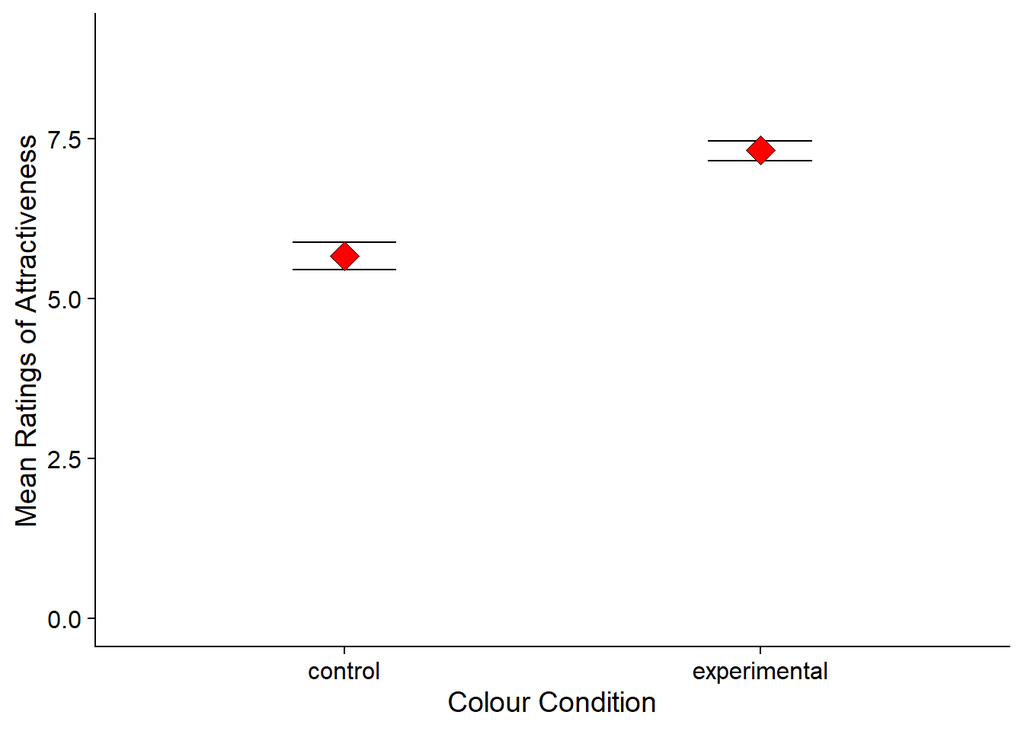

In conclusion, participants in the red experimental condition (*M* = 7.31) perceived the man as more attractive compared to participants in the white control condition (*M* = 5.67). Results from the statistical analysis further conclude that the difference in between the mean attractiveness ratings in the two conditions was significant. Therefore, these findings support the operational hypothesis that colour does influence mean attractiveness ratings. Specifically, the image of the man in conjunction with red is perceived as more attractive.

During data inspection, the following errors were detected and changed accordingly:

YEARS variable was changed to numeric variable. A typo in the age of one participant was detected and therefore removed from the data. Additionally, another typo was detected in a condition variable and was fixed accordingly.

# Discussion

The results from our replication study of Elliot et al. (2010) experiment 1 support the operational hypothesis, that a red colour frame around an image of a moderately attractive man influences his mean attractiveness ratings. These results support Elliot et al. (2010) experiment 1 results (Red condition: *M* = 6.79, White condition: *M* = 5.67, p < .05). Therefore, these results provide further evidence for a red effect on male attractiveness. Furthermore, these results contribute to answering the conceptual hypothesis: *Does colour influence attractiveness?*

However, Elliot et al.’s (2010) study has some key implications and limitations that arguably have significant consequences for the interpretation of the study’s results. Francis (2013) argues that Elliot et al.’s (2010) study is subject to publication bias. He supports this argument by running further statistical analysis on Elliot et al.’s (2010) study results, where he found that the probability of rejecting the null hypothesis in all of Elliot et al.’s studies was very unlikely, and that one way they managed to do this was by having small sample sizes (Francis, 2013). A key limitation to Elliot et al. (2010) study is its lack of ecological validity, due to neglecting other factors or features that could affect attractiveness ratings, such as clothing, hair styles or facial expressions (Hesslinger et al., 2015). A second limitation was due to the experiment material being restrictive, as the participants were only shown one image of a Caucasian man (Hesslinger et al., 2015). By doing do, the study cannot account for the variability of physical appearance that is found in the real world, nor that people differ in what physical features they find attractive (Hesslinger et al., 2015). A third limitation is that the study cannot account neither cultural differences nor personal preferences for the colour red. Therefore, the results from the study may possibly be due to these confounding variables.

Similar replication studies of Elliot et al.’s (2010) experiment 1 have been conducted. Hesslinger et al. (2015) conducted two similar experiments as Elliot et al. (2010) to examine the same red effect. In their first experiment, they conducted a close replication of Elliot et al.’s experiment 1. The only differences were that both male and female participants were recruited (n = 89, male participants = 17), as well as a larger age range (18-51 years old, *M* age = 21.9) (Hesslinger et al., 2015). Results from this experiment found that difference in mean attractiveness ratings in both conditions were not significant (p = .360). Their second experiment was conducted similarly, however only female participants were recruited (n = 32), and they added a new independent variable: apparel style. Results from this experiment again found that there was no significant difference between the two colour conditions on perceived attractiveness. However, they found that men in formal apparel were as perceived significantly more attractive than men in casual wear (Hesslinger et al., 2015). These findings indicate that the colour red does not have any effect on men’s perceived attractiveness, and therefore do not support Elliot et al.’s (2010) findings or our own findings. Instead, Hesslinger et al.’s (2015) findings suggest that other variables, such as apparel style, have a significant effect on perceived attractiveness.

Lehmann et al. (2018) conducted a meta-analysis of studies that tested the red-romance hypothesis: *red enhances heterosexual attraction in romantic contexts*. The results of their meta-analysis concluded that there was a significant red effect (p = .0004) for men rating women’s attractiveness. Thus, men perceive women as more attractive in conjunction with the colour red. Additionally, their results concluded that there was a small red effect (p = .03) for women rating men. However, this significance level is arguably very small (Lehmann et al., 2018), and could suggest that these results have occurred by chance.

By comparing our results to Hesslinger et al.’s (2015) results, as well as considering the implications and limitations of Elliot et al.’s (2010) study, our findings are very conflicting. Arguably, our study’s results could have possibility occurred by chance – especially when considering the results from the meta-analysis study as well as the publication bias claims. Since this study does not account for variability in physical appearance nor other factors such as ethnicity and age of the man used in the image, it is hard to rule out that the colour red alone effected the attractiveness ratings.

In order to investigate the conceptual hypothesis further: *Does colour influence attractiveness?*, future studies should focus on establishing if there is a red effect whilst ruling out any possible confounding variables that could possibly determine the outcome. Additionally, future studies should focus on the variability of physical appearance as well as personal preferences. An example of this would be to use multiple images of men from different age and ethnicity groups, as well as examining the individual participants personal preferences for male appearance. By doing this, the studies will become more ecologically valid as well as more precise in determining if colour does in fact affect the perception of male attractiveness.

In conclusion, the results from our replication study suggest that men in conjunction with the colour red are perceived as more attractive than men in conjunction with white – and therefore are similar to the original findings in Elliot et al. (2010). However, when comparing our study’s results to other replication studies of the same experiment, our results become conflicting. When considering the limitations in Elliot et al.’s (2010) study, that it lacks ecological validity by not accounting for the variability in physical appearance or personal preferences for attraction, the results of our study could indicate that they have occurred by chance or are due to unknown confounding variables – even though our difference in means was found to be significant. Therefore, future studies should focus on these limitations in order to determine if the red effect does in fact exist.

[Total word count: 1817]

# References

Elliot, A. J., Niesta Kayser, D., Greitemeyer, T., Lichtenfeld, S., Gramzow, R. H., Maier, M. A., & Liu, H. (2010). Red, rank, and romance in women viewing men. *Journal of Experimental Psychology: General, 139* (3), 399–417.

Francis, G. (2013). Publication bias in “Red, rank, and romance in women viewing men,” by Elliot et al. (2010). *Journal of Experimental Psychology: General, 142* (1), 292–296.

Hesslinger, V. M., Goldbach, L., & Carbon, C.-C. (2015). Men in red: A reexamination of the red-attractiveness effect. *Psychonomic Bulletin & Review, 22* (4), 1142–1148.

Lehmann, G. K., Elliot, A. J., & Calin-Jageman, R. J. (2018). Meta-Analysis of the Effect of Red on Perceived Attractiveness. *Evolutionary Psychology, 16* (4), 1474704918802412.